# VUB - Machine Learning - Python Tutorial

Adapted from the Stanford cs228 tutorial (https://github.com/kuleshov/cs228-material)

## Introduction

Python is a great general-purpose programming language on its own, but with the help of a few popular libraries (numpy, scipy, matplotlib) it becomes a powerful environment for scientific computing.

This section will serve as a quick crash course both on the Python programming language and on the use of Python for scientific computing as part of the Machine Learning course.

In this tutorial, we will cover:

## Basics of Python

Python is a high-level, dynamically typed multiparadigm programming language. Python code is often said to be almost like pseudocode, since it allows you to express very powerful ideas in very few lines of code while being very readable. As an example, here is an implementation of the classic quicksort algorithm in Python:

```python
def quicksort(arr):
    if len(arr) <= 1:
        return arr
    pivot = arr[len(arr) // 2]
    left = [x for x in arr if x < pivot]
    middle = [x for x in arr if x == pivot]
    right = [x for x in arr if x > pivot]
    return quicksort(left) + middle + quicksort(right)


print(quicksort([3, 6, 8, 10, 1, 2, 1]))
```

```
[1, 1, 2, 3, 6, 8, 10]
```

### Python versions and Tools

You can check your Python version at the command line by running `python --version`. For this course, we will be using Python 3. We recommend that you install [Anaconda](https://www.anaconda.com/products/individual)(a package/environment manager and Python distribution) for configuring and managing your Python setup during this course.

### Setting up your virtual environment

After installing Anaconda, you can execute the following steps to setup a fresh Python environment for this course.

1. Run `conda create --name ml-2223`. This creates a new virtual environment with the name ml-2223. Virtual environments are useful to manage development environments. For example, if one course relies on a version of SomePackage which is incompatible with this course's version of SomeOtherPackage, separating them in different virtual environments will ensure that no problems occur.
2. Run `conda activate ml-2223`. This activates your new virtual environment. You should now see `(ml-2223)` as a prefix in your terminal.
3. Run `conda install numpy scipy pandas scikit-learn matplotlib`. This installs the necessary packages for this course. Note that you will have to type `y` at a certain point in the installation to also install additional dependencies.

### Basic data types

#### Numbers

Integers and floats work as you would expect from other languages:

```python
x = 3
print(x, type(x))
y = 4
print(y)
```

```
3 <class 'int'>
4
```

```python
print(x)
print(x + 1)  # Addition;
print(x - 1)  # Subtraction;
print(x * 2)  # Multiplication;
print(x ** 2)  # Exponentiation;
```

```
3
4
2
6
9
```

```python
print(x)
x += 1
print(x)  # Prints "4"
x *= 2
print(x)  # Prints "8"
```

```
3
4
8
```

```python
y = 2.5
print(type(y))
print(y, y + 1, y * 2, y ** 2)
```

```
<class 'float'>
2.5 3.5 5.0 6.25
```

Note that unlike many languages, Python does not have unary increment (x++) or decrement (x--) operators.

Python also has built-in types for long integers and complex numbers; you can find all of the details in the [documentation](https://docs.python.org/3/library/stdtypes.html#numeric-types-int-float-long-complex).

#### Booleans

Python implements all of the usual operators for Boolean logic, but uses English words rather than symbols (`&&`, `||`, etc.):

```python
t, f = True, False
print(type(t))
```

```
<class 'bool'>
```

Now let's look at the operations:

```python
print(t and f)  # Logical AND;
print(t or f)  # Logical OR;
print(not t)  # Logical NOT;
print(t != f)  # Logical XOR;
```

```
False
True
False
True
```

#### Strings

```python
hello = 'hello'  # String literals can use single quotes
world = "world"  # or double quotes; it does not matter.
print(hello, len(hello))
```

```
hello 5
```

```python
hw = hello + ' ' + world  # String concatenation
print(hw)
```

```
hello world
```

```python
hw12 = '%s %s %d' % (hello, world, 12)  # sprintf style string formatting
print(hw12)  # prints "hello world 12"
```

```
hello world 12
```

String objects have a bunch of useful methods; for example:

```python
s = "hello"
print(s.capitalize())  # Capitalize a string; prints "Hello"
print(s.upper())  # Convert a string to uppercase; prints "HELLO"
print(s.rjust(7))  # Right-justify a string, padding with spaces; prints "  hello"
print(s.center(7))  # Center a string, padding with spaces; prints " hello "
print(s.replace('l', '(ell)'))  # Replace all instances of one substring with another;
# prints "he(ell)(ell)o"
print('  world '.strip())  # Strip leading and trailing whitespace; prints "world"
```

```
Hello
HELLO
  hello
 hello
he(ell)(ell)o
world
```

You can find a list of all string methods in the [documentation](https://docs.python.org/3/library/stdtypes.html#string-methods).

### Containers

Python includes several built-in container types: lists, dictionaries, sets, and tuples.

#### Lists

A list is the Python equivalent of an array, but is resizeable and can contain elements of different types:

```python
xs = [3, 1, 2]  # Create a list
print(xs, xs[2])
print(xs[-1])  # Negative indices count from the end of the list; prints "2"
```

```
[3, 1, 2] 2
2
```

```python
xs[2] = 'foo'  # Lists can contain elements of different types
print(xs)
```

```
[3, 1, 'foo']
```

```python
xs.append('bar')  # Add a new element to the end of the list
print(xs)
```

```
[3, 1, 'foo', 'bar']
```

```python
x = xs.pop()  # Remove and return the last element of the list
print(x, xs)
```

```
bar [3, 1, 'foo']
```

As usual, you can find all the gory details about lists in the [documentation](https://docs.python.org/3/tutorial/datastructures.html#more-on-lists).

#### Slicing

In addition to accessing list elements one at a time, Python provides concise syntax to access sublists; this is known as slicing:

```python
nums = list(range(5))  # range is a built-in function that creates a list of integers
print(nums)
print(nums[2:4])  # Get a slice from index 2 to 4 (exclusive);
print(nums[2:])  # Get a slice from index 2 to the end;
print(nums[:2])  # Get a slice from the start to index 2 (exclusive);
print(nums[:])  # Get a slice of the whole list;
print(nums[:-1])  # Slice indices can be negative;
nums[2:4] = [8, 9]  # Assign a new sublist to a slice
print(nums)
```

```
[0, 1, 2, 3, 4]
[2, 3]
[2, 3, 4]
[0, 1]
[0, 1, 2, 3, 4]
[0, 1, 2, 3]
[0, 1, 8, 9, 4]
```

#### Loops

You can loop over the elements of a list like this:

```python
animals = ['cat', 'dog', 'monkey']
for animal in animals:
    print(animal)
```

```
cat
dog
monkey
```

If you want access to the index of each element within the body of a loop, use the built-in `enumerate` function:

```python
animals = ['cat', 'dog', 'monkey']
for idx, animal in enumerate(animals):
    print('#%d: %s' % (idx + 1, animal))
```

```
#1: cat
#2: dog
#3: monkey
```

#### List comprehensions:

When programming, frequently we want to transform one type of data into another. As a simple example, consider the following code that computes square numbers:

```python
nums = [0, 1, 2, 3, 4]
squares = []
for x in nums:
    squares.append(x ** 2)
print(squares)
```

```
[0, 1, 4, 9, 16]
```

You can make this code simpler using a list comprehension:

```python
nums = [0, 1, 2, 3, 4]
squares = [x ** 2 for x in nums]
print(squares)
```

```
[0, 1, 4, 9, 16]
```

List comprehensions can also contain conditions:

```python
nums = [0, 1, 2, 3, 4]
even_squares = [x ** 2 for x in nums if x % 2 == 0]
print(even_squares)
```

```
[0, 4, 16]
```

#### Dictionaries

A dictionary stores (key, value) pairs, similar to a `Map` in Java or an object in Javascript. You can use it like this:

```python
d = {'cat': 'cute', 'dog': 'furry'}  # Create a new dictionary with some data
print(d['cat'])  # Get an entry from a dictionary; prints "cute"
print('cat' in d)  # Check if a dictionary has a given key; prints "True"
```

```
cute
True
```

```python
d['fish'] = 'wet'  # Set an entry in a dictionary
print(d['fish'])  # Prints "wet"
```

```
wet
```

```python
print(d['monkey'])  # KeyError: 'monkey' not a key of d
```

```
---------------------------------------------------------------------------
KeyError                                  Traceback (most recent call last)
Input In [24], in <cell line: 1>()
----> 1 print(d['monkey'])

KeyError: 'monkey'
```

```python
print(d.get('monkey', 'N/A'))  # Get an element with a default; prints "N/A"
print(d.get('fish', 'N/A'))  # Get an element with a default; prints "wet"
```

```
N/A
wet
```

```python
del d['fish']  # Remove an element from a dictionary
print(d.get('fish', 'N/A'))  # "fish" is no longer a key; prints "N/A"
```

```
N/A
```

You can find all you need to know about dictionaries in the [documentation](https://docs.python.org/3/library/stdtypes.html#dict).

It is easy to iterate over the keys in a dictionary:

```python
d = {'person': 2, 'cat': 4, 'spider': 8}
for animal in d:
    legs = d[animal]
    print('A %s has %d legs' % (animal, legs))
```

```
A person has 2 legs
A cat has 4 legs
A spider has 8 legs
```

```python
d = {'person': 2, 'cat': 4, 'spider': 8}
for animal, legs in d.items():
    print('A %s has %d legs' % (animal, legs))
```

```
A person has 2 legs
A cat has 4 legs
A spider has 8 legs
```

Dictionary comprehensions: These are similar to list comprehensions, but allow you to easily construct dictionaries. For example:

```python
nums = [0, 1, 2, 3, 4]
even_num_to_square = {x: x ** 2 for x in nums if x % 2 == 0}
print(even_num_to_square)
```

```
{0: 0, 2: 4, 4: 16}
```

#### Sets

A set is an unordered collection of distinct elements. As a simple example, consider the following:

```python
animals = {'cat', 'dog'}
print('cat' in animals)  # Check if an element is in a set; prints "True"
print('fish' in animals)  # prints "False"
```

```
True
False
```

```python
animals.add('fish')  # Add an element to a set
print('fish' in animals)
print(len(animals))  # Number of elements in a set;
```

```
True
3
```

```python
animals.add('cat')  # Adding an element that is already in the set does nothing
print(len(animals))
animals.remove('cat')  # Remove an element from a set
print(len(animals))
```

```
3
2
```

*Loops*: Iterating over a set has the same syntax as iterating over a list; however since sets are unordered, you cannot make assumptions about the order in which you visit the elements of the set:

```python
animals = {'cat', 'dog', 'fish'}
for idx, animal in enumerate(animals):
    print('#%d: %s' % (idx + 1, animal))
# Prints "#1: fish", "#2: dog", "#3: cat"
```

```
#1: fish
#2: dog
#3: cat
```

Set comprehensions: Like lists and dictionaries, we can easily construct sets using set comprehensions:

```python
from math import sqrt

print({int(sqrt(x)) for x in range(30)})
```

```
{0, 1, 2, 3, 4, 5}
```

#### Tuples

A tuple is an (immutable) ordered list of values. A tuple is in many ways similar to a list; one of the most important differences is that tuples can be used as keys in dictionaries and as elements of sets, while lists cannot. Here is a trivial example:

```python
d = {(x, x + 1): x for x in range(10)}  # Create a dictionary with tuple keys
t = (5, 6)  # Create a tuple
print(type(t))
print(d[t])
print(d[(1, 2)])
```

```
<class 'tuple'>
5
1
```

```python
t[0] = 1
```

```
---------------------------------------------------------------------------
TypeError                                 Traceback (most recent call last)
Input In [36], in <cell line: 1>()
----> 1 t[0] = 1

TypeError: 'tuple' object does not support item assignment
```

### Functions

Python functions are defined using the `def` keyword. For example:

```python
def sign(x):
    if x > 0:
        return 'positive'
    elif x < 0:
        return 'negative'
    else:
        return 'zero'


for x in [-1, 0, 1]:
    print(sign(x))
```

```
negative
zero
positive
```

We will often define functions to take optional keyword arguments, like this:

```python
def hello(name, loud=False):
    if loud:
        print('HELLO, %s' % name.upper())
    else:
        print('Hello, %s!' % name)


hello('Bob')
hello('Fred', loud=True)
```

```
Hello, Bob!
HELLO, FRED
```

### Classes

The syntax for defining classes in Python is straightforward:

```python
class Greeter:

    # Constructor
    def __init__(self, name):
        self.name = name  # Create an instance variable

    # Instance method
    def greet(self, loud=False):
        if loud:
            print('HELLO, %s!' % self.name.upper())
        else:
            print('Hello, %s' % self.name)


g = Greeter('Fred')  # Construct an instance of the Greeter class
g.greet()  # Call an instance method; prints "Hello, Fred"
g.greet(loud=True)  # Call an instance method; prints "HELLO, FRED!"
```

```
Hello, Fred
HELLO, FRED!
```

## Numpy

Numpy is the core library for scientific computing in Python. It provides a high-performance multidimensional array object, and tools for working with these arrays.

To use Numpy, we first need to import the `numpy` package:

```python
import numpy as np
```

### Arrays

A numpy array is a grid of values, all of the same type, and is indexed by a tuple of nonnegative integers. The number of dimensions is the rank of the array; the shape of an array is a tuple of integers giving the size of the array along each dimension.

We can initialize numpy arrays from nested Python lists, and access elements using square brackets:

```python
a = np.array([1, 2, 3])  # Create a rank 1 array
print(type(a), a.shape, a[0], a[1], a[2])
a[0] = 5  # Change an element of the array
print(a)
```

```
<class 'numpy.ndarray'> (3,) 1 2 3
[5 2 3]
```

```python
b = np.array([[1, 2, 3], [4, 5, 6]])  # Create a rank 2 array
print(b)
```

```
[[1 2 3]
 [4 5 6]]
```

```python
print(b.shape)
print(b[0, 0], b[0, 1], b[1, 0])  #row, column
```

```
(2, 3)
1 2 4
```

Numpy also provides many functions to create arrays:

```python
a = np.zeros((2, 2))  # Create an array of all zeros
print(a)
```

```
[[0. 0.]
 [0. 0.]]
```

```python
b = np.ones((1, 2))  # Create an array of all ones
print(b)
```

```
[[1. 1.]]
```

```python
c = np.full((2, 2), 7)  # Create a constant array
print(c)
```

```
[[7 7]
 [7 7]]
```

```python
d = np.eye(2)  # Create a 2x2 identity matrix
print(d)
```

```
[[1. 0.]
 [0. 1.]]
```

```python
e = np.random.random((2, 2))  # Create an array filled with random values
print(e)
```

```
[[0.0546471  0.70565884]
 [0.57637993 0.37359793]]
```

### Array indexing

Numpy offers several ways to index into arrays.

Slicing: Similar to Python lists, numpy arrays can be sliced. Since arrays may be multidimensional, you must specify a slice for each dimension of the array:

```python
import numpy as np

# Create the following rank 2 array with shape (3, 4)
# [[ 1  2  3  4]
#  [ 5  6  7  8]
#  [ 9 10 11 12]]
a = np.array([[1, 2, 3, 4], [5, 6, 7, 8], [9, 10, 11, 12]])

# Use slicing to pull out the subarray consisting of the first 2 rows
# and columns 1 and 2; b is the following array of shape (2, 2):
# [[2 3]
#  [6 7]]
b = a[:2, 1:3]
print(b)
```

```
[[2 3]
 [6 7]]
```

A slice of an array is a view into the same data, so modifying it will modify the original array.

```python
print(a)
print(b)
```

```
[[ 1  2  3  4]
 [ 5  6  7  8]
 [ 9 10 11 12]]
[[2 3]
 [6 7]]
```

```python
print(a[0, 1])
b[0, 0] = 77  # b[0, 0] is the same piece of data as a[0, 1]
print(a[0, 1])
print(a)
```

```
2
77
[[ 1 77  3  4]
 [ 5  6  7  8]
 [ 9 10 11 12]]
```

You can read all about numpy datatypes in the [documentation](http://docs.scipy.org/doc/numpy/reference/arrays.dtypes.html).

### Array math

Basic mathematical functions operate elementwise on arrays, and are available both as operator overloads and as functions in the numpy module:

```python
x = np.array([[1, 2], [3, 4]], dtype=np.float64)
y = np.array([[5, 6], [7, 8]], dtype=np.float64)

# Elementwise sum; both produce the array
print(x + y)
print(np.add(x, y))
```

```
[[ 6.  8.]
 [10. 12.]]
[[ 6.  8.]
 [10. 12.]]
```

```python
# Elementwise difference; both produce the array
print(x - y)
print(np.subtract(x, y))
```

```
[[-4. -4.]
 [-4. -4.]]
[[-4. -4.]
 [-4. -4.]]
```

```python
# Elementwise product; both produce the array
print(x * y)
print(np.multiply(x, y))
```

```
[[ 5. 12.]
 [21. 32.]]
[[ 5. 12.]
 [21. 32.]]
```

```python
# Elementwise division; both produce the array
# [[ 0.2         0.33333333]
#  [ 0.42857143  0.5       ]]
print(x / y)
print(np.divide(x, y))
```

```
[[0.2        0.33333333]
 [0.42857143 0.5       ]]
[[0.2        0.33333333]
 [0.42857143 0.5       ]]
```

```python
# Elementwise square root; produces the array
# [[ 1.          1.41421356]
#  [ 1.73205081  2.        ]]
print(np.sqrt(x))
```

```
[[1.         1.41421356]
 [1.73205081 2.        ]]
```

Note that `*` is elementwise multiplication, not matrix multiplication. We instead use the dot function to compute inner products of vectors, to multiply a vector by a matrix, and to multiply matrices. dot is available both as a function in the numpy module and as an instance method of array objects:

```python
x = np.array([[1, 2], [3, 4]])
y = np.array([[5, 6], [7, 8]])

v = np.array([9, 10])
w = np.array([11, 12])

# Inner product of vectors; both produce 219
print(v.dot(w))
print(np.dot(v, w))
```

```
219
219
```

```python
# Matrix / vector product; both produce the rank 1 array [29 67]
print(x.dot(v))
print(np.dot(x, v))
```

```
[29 67]
[29 67]
```

```python
# Matrix / matrix product; both produce the rank 2 array
# [[19 22]
#  [43 50]]
print(x.dot(y))
print(np.dot(x, y))
```

```
[[19 22]
 [43 50]]
[[19 22]
 [43 50]]
```

Numpy provides many useful functions for performing computations on arrays; one of the most useful is `sum`:

```python
x = np.array([[1, 2], [3, 4]])

print(np.sum(x))  # Compute sum of all elements; prints "10"
print(np.sum(x, axis=0))  # Compute sum of each column; prints "[4 6]"
print(np.sum(x, axis=1))  # Compute sum of each row; prints "[3 7]"
```

```
10
[4 6]
[3 7]
```

You can find the full list of mathematical functions provided by numpy in the [documentation](http://docs.scipy.org/doc/numpy/reference/routines.math.html).

Apart from computing mathematical functions using arrays, we frequently need to reshape or otherwise manipulate data in arrays. The simplest example of this type of operation is transposing a matrix; to transpose a matrix, simply use the T attribute of an array object:

```python
print(x)
print(x.T)
print(x.reshape(4, ))
```

```
[[1 2]
 [3 4]]
[[1 3]
 [2 4]]
[1 2 3 4]
```

### Broadcasting

Broadcasting is a powerful mechanism that allows numpy to work with arrays of different shapes when performing arithmetic operations. Frequently we have a smaller array and a larger array, and we want to use the smaller array multiple times to perform some operation on the larger array.

```python
import numpy as np

# We will add the vector v to each row of the matrix x,
# storing the result in the matrix y
x = np.array([[1, 2, 3], [4, 5, 6], [7, 8, 9], [10, 11, 12]])
v = np.array([1, 0, 1])
print(x)
print(v)
```

```
[[ 1  2  3]
 [ 4  5  6]
 [ 7  8  9]
 [10 11 12]]
[1 0 1]
```

Numpy broadcasting allows us to perform this computation without actually creating multiple copies of v or looping over x:

```python
# We will add the vector v to each row of the matrix x,
# storing the result in the matrix y
x = np.array([[1, 2, 3], [4, 5, 6], [7, 8, 9], [10, 11, 12]])
v = np.array([1, 0, 1])
y = x + v  # Add v to each row of x using broadcasting
print(x.shape, v.shape)
print(y)
```

```
(4, 3) (3,)
[[ 2  2  4]
 [ 5  5  7]
 [ 8  8 10]
 [11 11 13]]
```

Broadcasting typically makes your code more concise and faster, so you should strive to use it where possible. For more information you can read the explanation from the [documentation](http://docs.scipy.org/doc/numpy/user/basics.broadcasting.html) or this [explanation](http://wiki.scipy.org/EricsBroadcastingDoc).

Functions that support broadcasting are known as universal functions. You can find the list of all universal functions in the [documentation](http://docs.scipy.org/doc/numpy/reference/ufuncs.html#available-ufuncs).

This brief overview has touched on many of the important things that you need to know about numpy, but is far from complete. Check out the [numpy reference](http://docs.scipy.org/doc/numpy/reference/) to find out much more about numpy.

## Pandas

Pandas is a library for analysing and manipulating datasets in Python. As you will use it during this course, as well as in the course project, we will briefly introduce it here.

```python
import pandas as pd
```

### Loading datasets

Loading datasets is very easy in Pandas and can be accomplished in a single line of code. Note that there are a lot of optional parameters you can pass to this function, which you check out in [the documentation](https://pandas.pydata.org/docs/reference/api/pandas.read_csv.html).

```python
df = pd.read_csv('dataset.csv')
```

```python
df.head()
```

|  | Continent | Country | Population | Area |
| --- | --- | --- | --- | --- |
| 0 | Asia | Afghanistan | 40099462 | 652864 |
| 1 | Europe | Belgium | 11358357 | 30528 |
| 2 | Africa | Egypt | 82868000 | 1001450 |
| 3 | Asia | Singapore | 5941060 | 697 |
| 4 | Europe | France | 67348000 | 547030 |

### Basic operations

It is often useful to make subselections of the dataframe, either based on the columns or on the rows.

```python
column_subset = df[['Country', 'Population']]  # Take only the country and population columns.
column_subset.head()
```

|  | Country | Population |
| --- | --- | --- |
| 0 | Afghanistan | 40099462 |
| 1 | Belgium | 11358357 |
| 2 | Egypt | 82868000 |
| 3 | Singapore | 5941060 |
| 4 | France | 67348000 |

```python
row_subset = df[df['Continent'] == 'Asia']  # Take only rows where the country is part of Asia.
row_subset.head()
```

|  | Continent | Country | Population | Area |
| --- | --- | --- | --- | --- |
| 0 | Asia | Afghanistan | 40099462 | 652864 |
| 3 | Asia | Singapore | 5941060 | 697 |
| 6 | Asia | Vietnam | 97468029 | 331212 |

```python
row_subset = df[-3:]  # Take only the last 3 rows.
row_subset.head()
```

|  | Continent | Country | Population | Area |
| --- | --- | --- | --- | --- |
| 6 | Asia | Vietnam | 97468029 | 331212 |
| 7 | Europe | Norway | 5295619 | 385203 |
| 8 | Africa | Zimbabwe | 11392629 | 390580 |

### Arithmetic operations

Pandas supports many of the most used operations you might want to do on datasets. We illustrate how to take sums and maximums of, subsets of, the dataset.

```python
totals = df.sum()
population_total = totals['Population']
area_total = totals['Area']
print(f'The total population and area represented in this dataset is: {population_total} and {area_total}')
```

```
The total population and area represented in this dataset is: 321794156 and 4167888
```

```python
max_row = df['Population'].idxmax()
country = df.iloc[max_row]['Country']
population = df.iloc[max_row]['Population']

print(f'{country} has the largest population of {population}')
```

```
Vietnam has the largest population of 97468029
```

```python
africa_samples = df[df['Continent'] == 'Africa']  # Get the samples from africa. and take the mean of their population
mean_africa = africa_samples['Population'].mean()  # Take the mean of their population.
print(f'Africa alone has a population mean of {mean_africa}')
```

```
Africa alone has a population mean of 31427876.333333332
```

### Grouping

The final thing that we want to demonstrate in this short overview is the grouping functionality. Sometimes it will be useful to compute values for data samples which are part of some group. Below, we show you how to do this using Pandas.

```python
continent_groups = df.groupby(['Continent'])  # Groups all the samples by their continent.
```

```python
means = continent_groups.mean()
print(means)
```

```
             Population           Area
Continent
Africa     3.142788e+07  740118.000000
Asia       4.783618e+07  328257.666667
Europe     2.800066e+07  320920.333333
```

### Creating and storing new datasets

The last thing we will do is generate and save a completely new dataset. In the next section, we can use this dataset to construct visualisations.

```python
x = np.arange(0, 3 * np.pi, 0.1)

y_sin = np.sin(x)  # Generate a sine wave.
y_cos = np.cos(x)  # Generate a cosine wave.
```

```python
data_dict = {'X': x, 'Sin': y_sin, 'Cos': y_cos}
df = pd.DataFrame.from_dict(data_dict)
df.head()
```

|  | X | Sin | Cos |
| --- | --- | --- | --- |
| 0 | 0.0 | 0.000000 | 1.000000 |
| 1 | 0.1 | 0.099833 | 0.995004 |
| 2 | 0.2 | 0.198669 | 0.980067 |
| 3 | 0.3 | 0.295520 | 0.955336 |
| 4 | 0.4 | 0.389418 | 0.921061 |

```python
df.to_csv('sine-cosine.csv', index=False)
```

## Matplotlib

The final library we introduce is Matplotlib, a popular plotting library. Matplotlit provides a plotting system similar to that of MATLAB by giving access to the `matplotlib.pyplot` module.

```python
import matplotlib.pyplot as plt
```

By running this special iPython command, we will be displaying plots inline:

```python
%matplotlib inline
```

### Plotting

The most important function in `matplotlib` is plot, which allows you to plot 2D data. Here is a simple example:

```python
df = pd.read_csv('sine-cosine.csv')  # Read the CSV file with sine and cosine data.
x = df['X'].tolist()  # Extract the lists.
y_sin = df['Sin'].tolist()
y_cos = df['Cos'].tolist()
```

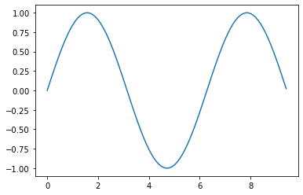

```python
# Plot the points using matplotlib
plt.plot(x, y_sin)
```

With just a little bit of extra work we can easily plot multiple lines at once, and add a title, legend, and axis labels:

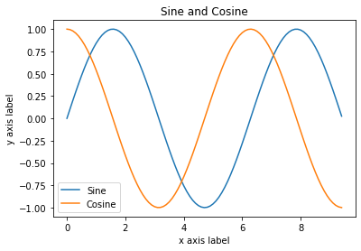

```python
# Plot the points using matplotlib
plt.plot(x, y_sin)
plt.plot(x, y_cos)
plt.xlabel('x axis label')
plt.ylabel('y axis label')
plt.title('Sine and Cosine')
plt.legend(['Sine', 'Cosine'])
```

### Subplots

You can plot different things in the same figure using the subplot function. Here is an example:

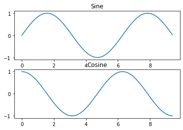

```python
# Set up a subplot grid that has height 2 and width 1,
# and set the first such subplot as active.
plt.subplot(2, 1, 1)

# Make the first plot
plt.plot(x, y_sin)
plt.title('Sine')

# Set the second subplot as active, and make the second plot.
plt.subplot(2, 1, 2)
plt.plot(x, y_cos)
plt.title('Cosine')

# Show the figure.
plt.show()
```

You can read much more about the `subplot` function in the [documentation](http://matplotlib.org/api/pyplot_api.html#matplotlib.pyplot.subplot).